# R Notebook

# Preprocessing

## Parsing helper functions

```r
# Scales a vector to range [0, 1] s.t. 0 is the start, 1 is the end
unit_scale_mt <- function(x) {
  return((x-x[1])/(x[length(x)]-x[1]))
}
```

## Fetch the data & general preprocessing

```r
filename <- 'data-25.07.csv'
#filename <- 'data-sample.csv'
data_raw <- read_csv(filename)

# Remove some of the irrelevant columns
data <- data_raw %>%
  filter(
    submission_id >= 1508 &
    trial_name == "mousetracking_main"
  ) %>%
  select(
    submission_id,
    answer,
    correct_category,
    left_category,
    right_category,
    mt_times,
    mt_x,
    mt_y,
    type,
    animal
  )

# Add a direction of the answer and correct column
data <- data %>%
  mutate(
    dir = ifelse(answer == left_category, 'left', 'right'),
    correct = answer == correct_category
  )

data <- data %>%
  left_join(
    data_raw %>%
      select(submission_id, response) %>%
      filter(!is.na(response)) %>%
      rename(handed = response)
  )

# We need the id to key the time- and space-normalised tibbles
data <- tibble::rowid_to_column(data, "id")

# Store the moustracking data
mt_data <- tibble(
  id = data$id,
  times = data$mt_times,
  x = data$mt_x,
  y = data$mt_y
) %>%
  separate_rows(times, x, y, sep = ",", convert = TRUE)
# y is flipped
mt_data$y = -mt_data$y
# flip x if in left direction
mt_data <- mt_data %>%
  left_join(data %>% select(id, dir)) %>%
  mutate(x = ifelse(dir == "left", -x, x))

# Remove the now-defunct mt_* variables from data
data <- data %>% select(-mt_times, -mt_x, -mt_y)
```

```r
data %>%
  group_by(submission_id) %>%
  summarise(handed = first(handed)) %>%
  group_by(handed) %>%
  summarise(n = n())
```

| handed | n |
| --- | --- |
| left | 5 |
| right | 52 |

## Exclusion of outliers

```r
mt_data <- mt_data %>%
  mutate(outlier = FALSE)

repeat {
  times_rt <- mt_data %>%
    filter(!outlier) %>%
    group_by(id) %>%
    summarise(times = max(times))
  m <- median(times_rt$times)
  sigma <- sd(times_rt$times)
  z <- abs(times_rt$times - m) / sigma

  z_argmax <- which.max(z)
  if (z[z_argmax] > 3.5) {
    outlier_id <- times_rt$id[z_argmax]
    mt_data <- mt_data %>%
      mutate(outlier = outlier | id == outlier_id)
  } else {
    break
  }
}

mt_data %>% filter(outlier) %>% pull(id) %>% unique %>% length
```

```
## [1] 49
```

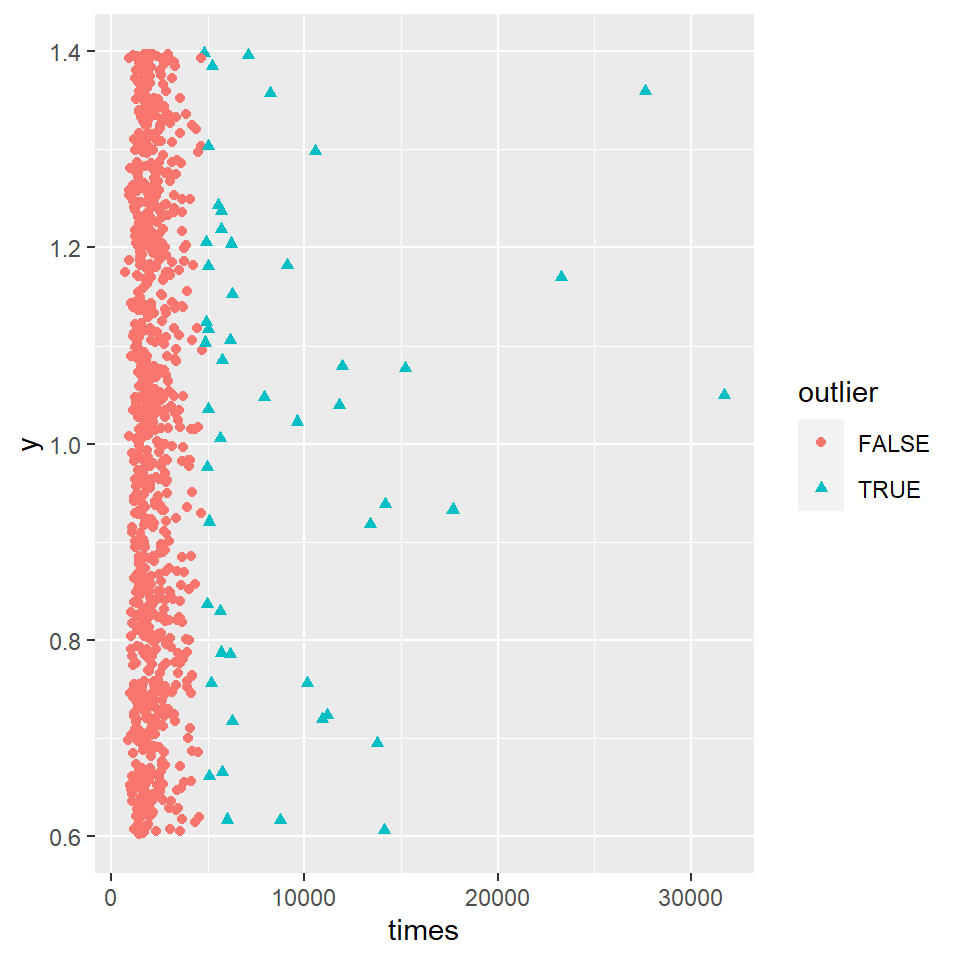

```r
mt_data %>%
  group_by(id, outlier) %>%
  summarise(times = max(times)) %>%
  ggplot(aes(x = times, y = 1)) +
  geom_point(aes(shape = outlier, color = outlier), position = position_jitter())
```

Remove outliers

```r
outliers <- mt_data %>%
  filter(outlier) %>%
  pull(id) %>%
  unique

mt_data <- mt_data %>%
  filter(!outlier) %>%
  select(-outlier)

for (i in 1:length(outliers)) {
  outlier <- outliers[i]
  data <- data %>%
    filter(id != outlier)
}
```

```r
outliers
```

```
##  [1]  57  82  85  86  93 197 201 289 360 369 370 378 382 384 396 402 442 443 447
## [20] 466 547 550 557 594 595 599 600 601 604 605 606 607 609 610 613 614 623 633
## [39] 637 660 732 742 743 785 787 840 884 902 909
```

```r
data %>% filter(!correct)
```

| id | submission_id | answer | correct_category | left_category | right_category | type | animal | dir | correct | handed |
| --- | --- | --- | --- | --- | --- | --- | --- | --- | --- | --- |
| 2 | 1721 | amphibian | reptile | reptile | amphibian | typical | Rattlesnake | right | FALSE | right |
| 6 | 1721 | reptile | bird | bird | reptile | typical | Hawk | right | FALSE | right |
| 7 | 1721 | reptile | fish | fish | reptile | atypical | Eel | right | FALSE | right |
| 11 | 1721 | fish | mammal | fish | mammal | atypical | Whale | left | FALSE | right |
| 12 | 1721 | bird | mammal | mammal | bird | atypical | Bat | right | FALSE | right |
| 16 | 1721 | mammal | reptile | mammal | reptile | typical | Alligator | left | FALSE | right |
| 20 | 1708 | amphibian | reptile | reptile | amphibian | typical | Rattlesnake | right | FALSE | right |
| 24 | 1708 | reptile | fish | reptile | fish | atypical | Eel | left | FALSE | right |
| 34 | 1678 | fish | mammal | mammal | fish | atypical | Whale | right | FALSE | right |
| 38 | 1678 | bird | mammal | mammal | bird | atypical | Bat | right | FALSE | right |

[output cut: 66 more lines]

Remove incorrect responses

```r
# We need the correct percentage of each participant
correct_data <- data %>%
  group_by(submission_id, type) %>%
  summarise(
    p = sum(correct) / length(correct)
  )
# Remove incorrect results from mt_data
incorrect <- data %>% filter(!correct) %>% pull(id)
for (i in 1:length(incorrect)) {
  incorrect_id = incorrect[i]

  mt_data <- mt_data %>% filter(id != incorrect_id)
}
# Remove incorrect results from data
data <- data %>% filter(correct)
```

## Time-normalised

We normalised the data into 101 bins. This is stored in its own tibble, keyed to the rest of the data.

```r
time_normalised = tribble(~id, ~step, ~x, ~y)

for (i in 1:nrow(data)) {
  item <- data[i,]
  mt_item <- mt_data %>% filter(id == item$id) %>%
    filter(x != 0 & y != 0)
  if (nrow(mt_item) < 2) {
    next
  }

  x <- approx(mt_item$times, mt_item$x, n=101)$y
  y <- approx(mt_item$times, mt_item$y, n=101)$y

  item <- tibble(
    id = i, step = 1:101, x = x, y = y,
    dir = item$dir, type = item$type,
    submission_id = item$submission_id
  )

  time_normalised <- bind_rows(time_normalised, item)
}
```

## Space-normalised

```r
space_normalised = tribble(~id, ~step, ~x, ~y)

for (i in 1:nrow(data)) {
  item <- data[i,]
  mt_item <- mt_data %>% filter(id == item$id) %>%
    filter(x != 0 & y != 0)
  if (nrow(mt_item) < 2) {
    next
  }
  mt_item <- mt_item %>% mutate(
    times = times - min(times)
  )

  bin_range <- c(0, 500, 1000, 1500)
  bins <- tibble(
    bin_cut = cut(mt_item$times, bin_range, include.lowest=TRUE),
    x = unit_scale_mt(mt_item$x),
    y = unit_scale_mt(mt_item$y)
  )

  bins <- bins %>%
    group_by(bin_cut) %>%
    summarise(
      x = mean(x),
      y = mean(y),
      .groups = 'drop'
    )

  # If a person finished before the last (or second-last) bin, their position
  # is (1,1) at that point in time. We adjust as such, so that our statistical
  # tests work.
  if (nrow(bins) == 1) {
    bins <- add_row(bins, bin_cut = '[500,1e+03]', x = 1, y = 1, .groups = 'drop')
  }
  if (nrow(bins) == 2) {
    bins <- add_row(bins, bin_cut = '[1e+03,1.5e+03]', x = 1, y = 1, .groups = 'drop')
  }
  # We drop anything beyond our 1.5 second bin.
  if (nrow(bins) > 3) {
    bins <- bins %>% filter(!is.na(bin_cut))
  }

  bins <- bins %>%
    mutate(
      id = i,
      step = 1:3,
      dir = item$dir,
      type = item$type,
      submission_id = item$submission_id
    )

  space_normalised <- bind_rows(space_normalised, bins)
}
```

## Other

```r
other_data <- tribble(
  ~id,
  ~distance_travelled,
  ~auc
)

# We can calculate these
data <- mt_data %>%
  group_by(id) %>%
  summarise(
    first_move = min(which(x != 0 | y != 0)),
    movement_init = times[first_move],
    movement_duration = max(times) - movement_init,
    total_rt = movement_init + movement_duration,
    # We take the first non-zero mouse position and calculate the angle from the origin. It's from the vertical so we reverse the usual atan2 input.
    angle = atan2(x[first_move],
                  y[first_move]) * 180/pi
  ) %>%
  select(-first_move) %>%
  left_join(data)

# The other metrics are a bit more specific, so we do them by hand
for (i in 1:nrow(data)) {
  mt_item <- mt_data %>% filter(id == data[[i, 1]])

  # We approximate the distance by each discrete mouse-movement step recorded.
  dist <- 0
  # We use the naive approach..
  for (j in 2:nrow(mt_item)) {
    dist <- dist + sqrt(
      (mt_item$x[j-1] - mt_item$x[j])^2 +
      (mt_item$y[j-1] - mt_item$y[j])^2
    )
  }

  # We need to find the straight line
  x <- mt_item$x
  y <- mt_item$y
  m <- (last(y) - first(y)) / (last(x) - first(x))
  b <- first(y) - m*first(x)
  f <- function(x) b + m * x
  # Subtract the line from y
  y <- y - f(x)
  # Approximate the area under the curve
  AUC <- auc(x, y, type = "linear", absolutearea = F)

  data_item <- tibble(
    id = data[[i, 1]],
    distance_travelled = dist,
    AUC = AUC
  )

  other_data <- rbind(other_data, data_item)
}

data <- data %>% left_join(other_data)
```

# Analysis

## Initial graphs

### Mean time-normalised trajectories

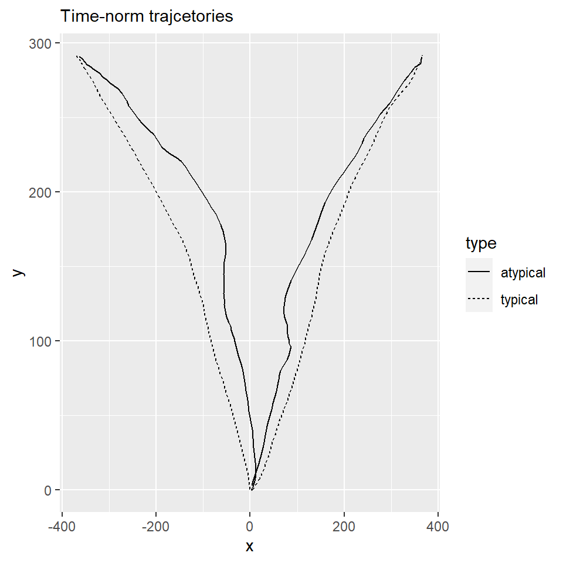

```r
ggtime_norm_lr <- time_normalised %>%
  group_by(step, dir, type) %>%
  summarise(
    x = mean(ifelse(dir == 'right', x, -x)),
    y = mean(y)
  ) %>%
  ggplot(aes(x, y, group = interaction(type, dir))) +
  geom_path(aes(linetype=type)) +
  theme(plot.title = element_text(size = 11)) +
  ggtitle("Time-norm trajcetories")
ggtime_norm_lr
```

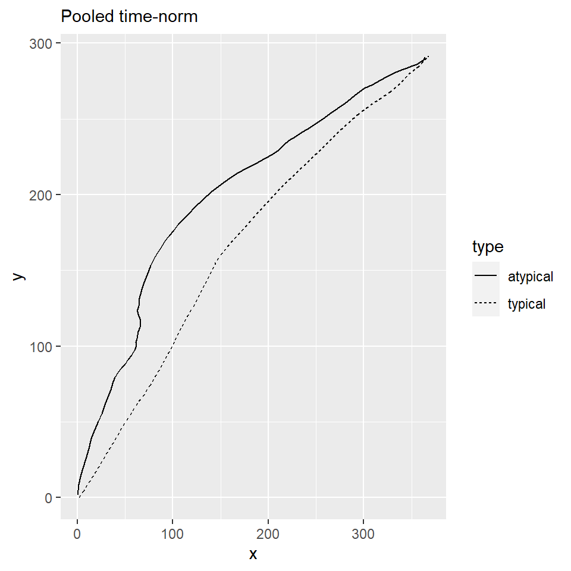

```r
ggtime_norm_pooled <- time_normalised %>%
  group_by(step, type) %>%
  summarise(
    x = mean(x),
    y = mean(y)
  ) %>%
  ggplot(aes(x, y, group = type)) +
  geom_path(aes(linetype=type)) +
  theme(plot.title = element_text(size = 11)) +
  ggtitle("Pooled time-norm")
ggtime_norm_pooled
```

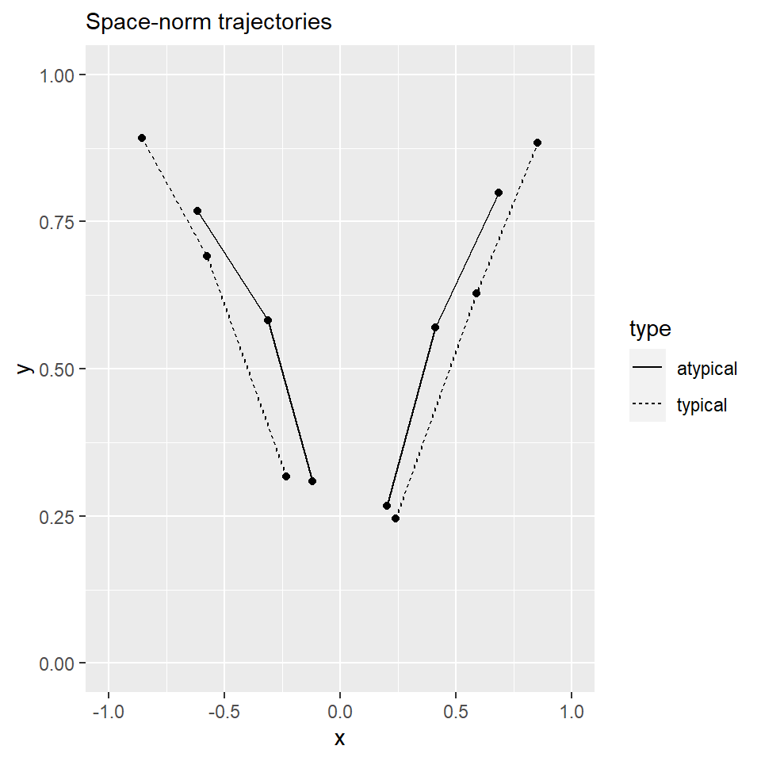

```r
ggspace_norm_lr <- space_normalised %>%
  filter(step <= 3) %>%
  group_by(step, dir, type) %>%
  summarise(
    x = mean(ifelse(dir=='right', x, -x)),
    y = mean(y)
  ) %>%
  ggplot(aes(x, y, group=interaction(type, dir))) +
  geom_path(aes(linetype=type)) +
  geom_point() +
  ylim(0, 1) +
  xlim(-1, 1) +
  theme(plot.title = element_text(size = 11)) +
  ggtitle("Space-norm trajectories")
ggspace_norm_lr
```

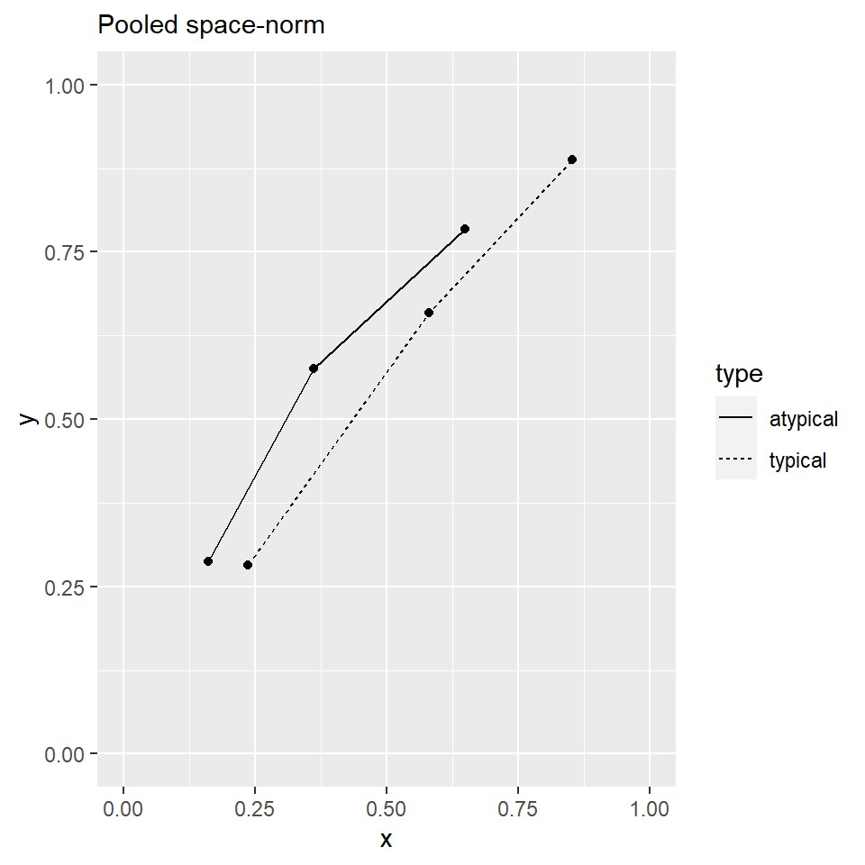

```r
ggspace_norm_pooled <- space_normalised %>%
  filter(step <= 3) %>%
  group_by(step, type) %>%
  summarise(
    x = mean(x),
    y = mean(y)
  ) %>%
  ggplot(aes(x, y, group=type)) +
  geom_path(aes(linetype=type)) +
  geom_point() +
  ylim(0, 1) +
  xlim(0, 1) +
  theme(plot.title = element_text(size = 11)) +
  ggtitle("Pooled space-norm")
ggspace_norm_pooled
```

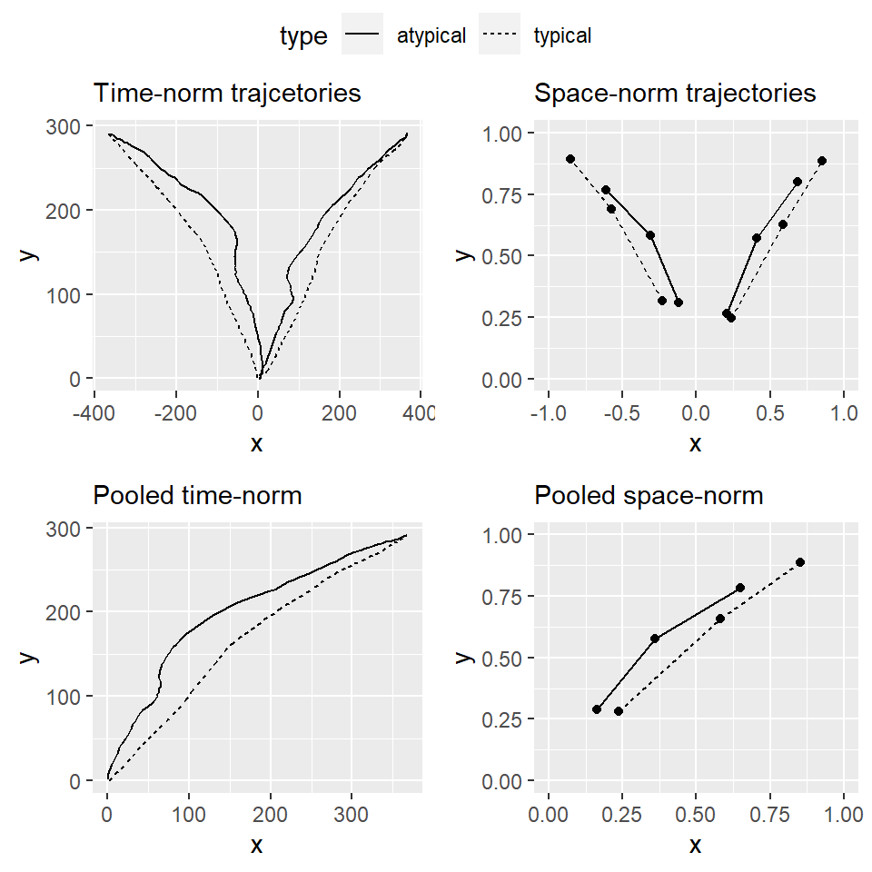

```r
ggarrange(ggtime_norm_lr, ggspace_norm_lr, ggtime_norm_pooled, ggspace_norm_pooled,
          #labels = c("Time-normalised trajectories", "Space-normalised trajectories", "Pooled time-normalised trajectories", "Pooled space-normalised trajectories"),
          common.legend = T)
```

```r
  ggsave("norm_space_plots.png")
```

## Correct proportion t-test

```r
correct_data %>%
  group_by(type) %>%
  summarise(
    mean = mean(p),
    sd = sd(p)
  )
```

| type | mean | sd |
| --- | --- | --- |
| atypical | 0.8300595 | 0.2089758 |
| typical | 0.9552366 | 0.1031254 |

```r
correct_t_data <- correct_data %>% spread(type, p)
t.test(correct_t_data$atypical, correct_t_data$typical)
```

```
##
##  Welch Two Sample t-test
##
## data:  correct_t_data$atypical and correct_t_data$typical
## t = -4.0266, df = 79.97, p-value = 0.0001279
## alternative hypothesis: true difference in means is not equal to 0
## 95 percent confidence interval:
##  -0.1870429 -0.0633112
## sample estimates:
## mean of x mean of y
## 0.8300595 0.9552366
```

## Time-normalised analysis

### t-test

```r
pvalues <- c()
for (i in 1:101) {
  step_data <- time_normalised %>%
    filter(step == i) %>%
    select(id, type, x)
  step_atypical <- step_data %>%
    filter(type == 'atypical') %>%
    pull(x)
  step_typical <- step_data %>%
    filter(type == 'typical') %>%
    pull(x)

  t_result = t.test(step_typical, step_atypical)
  if (is.nan(t_result$p.value)) {
    # Same datasets (usually at start with everything 0)
    pvalues <- append(pvalues, 1)
  } else {
    pvalues <- append(pvalues, t_result$p.value)
  }
}

tibble(step = 1:101, divergence = pvalues < 0.05)
```

| step | divergence |
| --- | --- |
| 1 | FALSE |
| 2 | FALSE |
| 3 | FALSE |
| 4 | FALSE |
| 5 | FALSE |
| 6 | FALSE |
| 7 | FALSE |
| 8 | FALSE |
| 9 | FALSE |
| 10 | FALSE |

[output cut: 91 more lines]

```r
rle(pvalues < 0.05)$lengths[rle(pvalues < 0.05)$values]
```

```
## [1] 54
```

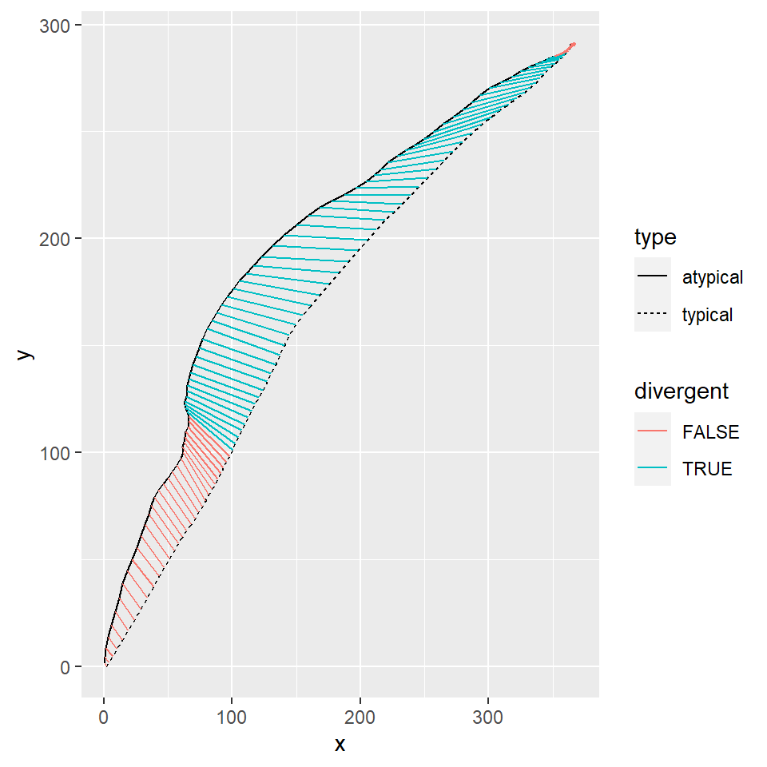

```r
time_normalised %>%
  group_by(step, type) %>%
  summarise(
    x = mean(x),
    y = mean(y)
  ) %>%
  add_column(divergent = rep(pvalues < 0.05, each=2)) %>%
  ggplot(aes(x, y, group = type)) +
  geom_path(aes(linetype=type)) +
#  geom_point(aes(color = divergent), size = 0.5) +
  geom_line(aes(group = step, color = divergent))
```

### ANOVA

```r
step_bins <- c(1, 33, 67, 101)
time_norm_anova_data <- time_normalised %>%
  select(submission_id, step, x, type) %>%
  mutate(bin = cut(step, step_bins, include.lowest=TRUE)) %>%
  select(submission_id, type, bin, x) %>%
  mutate(
    submission_id = as.factor(submission_id),
    type = as.factor(type)
  ) %>%
  group_by(submission_id, bin, type) %>%
  summarise(x = mean(x)) %>%
  # For some reason it's not dropping the grouping during summarise
  ungroup

time_norm_anova_result <- time_norm_anova_data %>%
  anova_test(
    dv = x, wid = submission_id,
    within = c(bin, type)
  )

get_anova_table(time_norm_anova_result)
```

|  | Effect | DFn | DFd | F | p | p<.05 | ges |
| --- | --- | --- | --- | --- | --- | --- | --- |
| 1 | bin | 1.44 | 73.35 | 427.610 | 6.40e-37 | * | 0.663 |
| 2 | type | 1.00 | 51.00 | 15.461 | 2.55e-04 | * | 0.044 |
| 3 | bin:type | 1.65 | 84.32 | 6.895 | 3.00e-03 | * | 0.013 |

```r
time_norm_anova_data %>%
  group_by(bin) %>%
  pairwise_t_test(
    x ~ type, paired = TRUE,
    p.adjust.method = "bonferroni"
  )
```

|  | bin | .y. | group1 | group2 | n1 | n2 | statistic | df | p | p.adj | p.adj.signif |
| --- | --- | --- | --- | --- | --- | --- | --- | --- | --- | --- | --- |
| 1 | [1,33] | x | atypical | typical | 52 | 52 | -2.407210 | 51 | 0.020000 | 0.020000 | * |
| 2 | (33,67] | x | atypical | typical | 52 | 52 | -3.732803 | 51 | 0.000478 | 0.000478 | *** |
| 3 | (67,101] | x | atypical | typical | 52 | 52 | -3.634910 | 51 | 0.000647 | 0.000647 | *** |

Significant difference in the first bin (p < 0.05) and the second and third binds (ps < 0.001)

## Space-normalised data

### ANOVA

```r
space_norm_anova_data <- space_normalised %>%
  select(submission_id, step, type, x) %>%
  group_by(submission_id, step, type) %>%
  summarise(x = mean(x)) %>%
  ungroup

space_norm_anova_data %>%
  anova_test(
    dv = x, wid = submission_id,
    within = c(step, type)
  ) %>%
  get_anova_table
```

|  | Effect | DFn | DFd | F | p | p<.05 | ges |
| --- | --- | --- | --- | --- | --- | --- | --- |
| 1 | step | 2 | 102 | 280.854 | 3.29e-42 | * | 0.407 |
| 2 | type | 1 | 51 | 42.436 | 3.18e-08 | * | 0.109 |
| 3 | step:type | 2 | 102 | 8.360 | 4.34e-04 | * | 0.015 |

```r
space_norm_anova_data %>%
  group_by(step) %>%
  pairwise_t_test(
    x ~ type, paired = TRUE,
    p.adjust.method = "bonferroni"
  )
```

|  | step | .y. | group1 | group2 | n1 | n2 | statistic | df | p | p.adj | p.adj.signif |
| --- | --- | --- | --- | --- | --- | --- | --- | --- | --- | --- | --- |
| 1 | 1 | x | atypical | typical | 52 | 52 | -3.093281 | 51 | 3.00e-03 | 3.00e-03 | ** |
| 2 | 2 | x | atypical | typical | 52 | 52 | -5.789289 | 51 | 4.38e-07 | 4.38e-07 | **** |
| 3 | 3 | x | atypical | typical | 52 | 52 | -6.048108 | 51 | 1.72e-07 | 1.72e-07 | **** |

## Other

### t-tests

#### Movement duration

```r
data %>%
  group_by(type) %>%
  summarise(
    movement_duration = mean(movement_duration)
  )
```

| type | movement_duration |
| --- | --- |
| atypical | 1736.937 |
| typical | 1347.219 |

```r
data %>%
  t_test(movement_duration ~ type)
```

|  | .y. | group1 | group2 | n1 | n2 | statistic | df | p |
| --- | --- | --- | --- | --- | --- | --- | --- | --- |
| 1 | movement_duration | atypical | typical | 222 | 565 | 5.310591 | 342.1477 | 1.97e-07 |

#### Total categorization time

```r
data %>%
  group_by(type) %>%
  summarise(
    total_rt = mean(total_rt)
  )
```

| type | total_rt |
| --- | --- |
| atypical | 2481.802 |
| typical | 2005.083 |

```r
data %>%
  t_test(total_rt ~ type)
```

|  | .y. | group1 | group2 | n1 | n2 | statistic | df | p |
| --- | --- | --- | --- | --- | --- | --- | --- | --- |
| 1 | total_rt | atypical | typical | 222 | 565 | 7.519575 | 356.9581 | 4.49e-13 |

#### Total distance travelled

```r
data %>%
  group_by(type) %>%
  summarise(
    distance_travelled = mean(distance_travelled)
  )
```

| type | distance_travelled |
| --- | --- |
| atypical | 838.5016 |
| typical | 664.2902 |

```r
data %>%
  t_test(distance_travelled ~ type)
```

|  | .y. | group1 | group2 | n1 | n2 | statistic | df | p |
| --- | --- | --- | --- | --- | --- | --- | --- | --- |
| 1 | distance_travelled | atypical | typical | 222 | 565 | 4.525374 | 277.8327 | 8.95e-06 |

#### Movement initiation latency

```r
data %>%
  group_by(type) %>%
  summarise(
    movement_init = mean(movement_init)
  )
```

| type | movement_init |
| --- | --- |
| atypical | 744.8649 |
| typical | 657.8637 |

```r
data %>%
  t_test(movement_init ~ type)
```

|  | .y. | group1 | group2 | n1 | n2 | statistic | df | p |
| --- | --- | --- | --- | --- | --- | --- | --- | --- |
| 1 | movement_init | atypical | typical | 222 | 565 | 1.563801 | 353.6564 | 0.119 |

#### Initial direction of the mouse trajectory

```r
data %>%
  group_by(type) %>%
  summarise(
    angle = mean(angle)
  )
```

| type | angle |
| --- | --- |
| atypical | 43.18995 |
| typical | 53.80584 |

```r
# TODO
```

### ANOVA

```r
other_anova_data <- data %>%
  group_by(submission_id, type) %>%
  summarise(
    movement_duration = mean(movement_duration),
    total_rt = mean(total_rt),
    distance_travelled = mean(distance_travelled),
    movement_init = mean(movement_init),
    angle = mean(angle)
  ) %>%
  ungroup
```

#### Movement duration

```r
other_anova_data %>%
  select(submission_id, type, movement_duration) %>%
  anova_test(
    dv = movement_duration,
    wid = submission_id,
    within = type
  ) %>%
  get_anova_table
```

|  | Effect | DFn | DFd | F | p | p<.05 | ges |
| --- | --- | --- | --- | --- | --- | --- | --- |
| 1 | type | 1 | 55 | 61.986 | 1.4e-10 | * | 0.087 |

#### Total categorization time

```r
other_anova_data %>%
  select(submission_id, type, total_rt) %>%
  anova_test(
    dv = total_rt,
    wid = submission_id,
    within = type
  ) %>%
  get_anova_table
```

|  | Effect | DFn | DFd | F | p | p<.05 | ges |
| --- | --- | --- | --- | --- | --- | --- | --- |
| 1 | type | 1 | 55 | 123.637 | 1.09e-15 | * | 0.198 |

#### Total distance travelled

```r
other_anova_data %>%
  select(submission_id, type, distance_travelled) %>%
  anova_test(
    dv = distance_travelled,
    wid = submission_id,
    within = type
  ) %>%
  get_anova_table
```

|  | Effect | DFn | DFd | F | p | p<.05 | ges |
| --- | --- | --- | --- | --- | --- | --- | --- |
| 1 | type | 1 | 55 | 19.124 | 5.5e-05 | * | 0.085 |

#### Movement initiation latency

```r
other_anova_data %>%
  select(submission_id, type, movement_init) %>%
  anova_test(
    dv = movement_init,
    wid = submission_id,
    within = type
  ) %>%
  get_anova_table
```

|  | Effect | DFn | DFd | F | p | p<.05 | ges |
| --- | --- | --- | --- | --- | --- | --- | --- |
| 1 | type | 1 | 55 | 11.558 | 0.001 | * | 0.011 |

#### Initial direction of the mouse trajectory

```r
other_anova_data %>%
  select(submission_id, type, angle) %>%
  anova_test(
    dv = angle,
    wid = submission_id,
    within = type
  ) %>%
  get_anova_table
```

|  | Effect | DFn | DFd | F | p | p<.05 | ges |
| --- | --- | --- | --- | --- | --- | --- | --- |
| 1 | type | 1 | 55 | 0.968 | 0.329 |  | 0.005 |

## Bimodality

```r
data %>%
  group_by(type) %>%
  summarise(AUC = mean(AUC))
```

| type | AUC |
| --- | --- |
| atypical | 39791.12 |
| typical | 16325.57 |

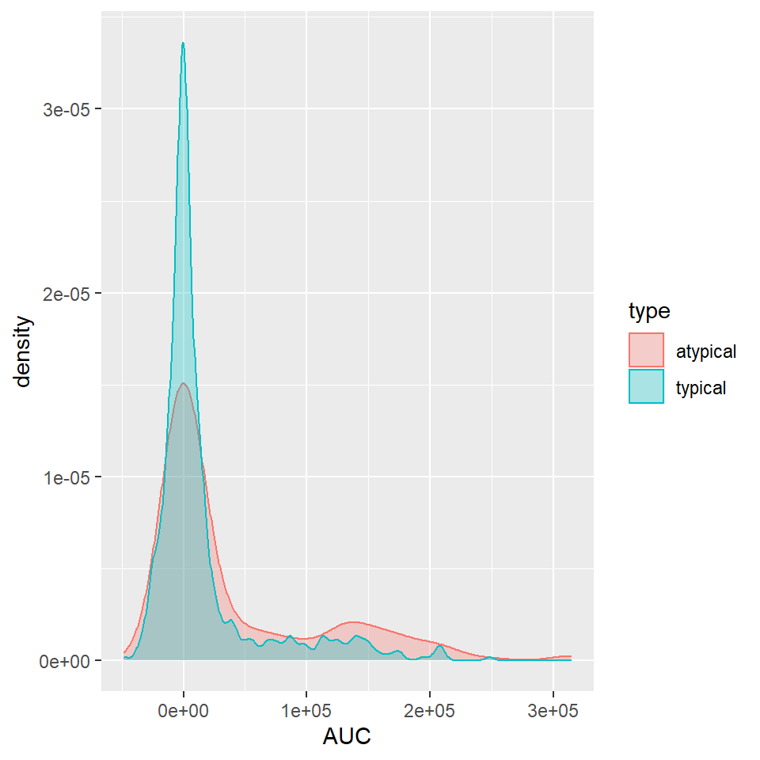

```r
data %>%
  ggplot(aes(x = AUC, group = type, color = type, fill = type)) +
  geom_density(alpha = 0.3)
```

```r
AUC_z <- abs(data$AUC - mean(data$AUC)) / sd(data$AUC)
tidy_AUC <- data %>%
  select(type, AUC) %>%
  mutate(AUC_z = (AUC - mean(AUC)) / sd(AUC))
```

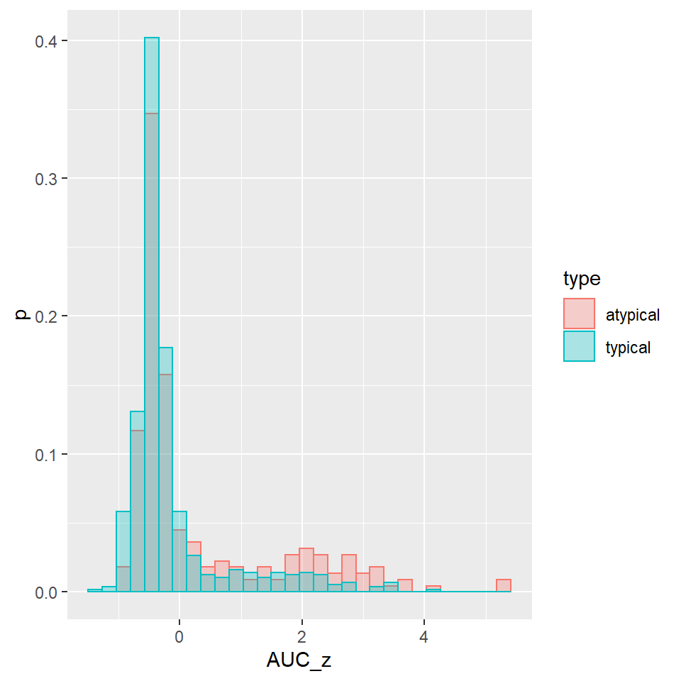

```r
tidy_AUC %>%
  ggplot(
    aes(
      AUC_z,
      y=c(..count..[..group..==1]/sum(..count..[..group..==1]),
          ..count..[..group..==2]/sum(..count..[..group..==2])),
      color = type,
      fill = type
    )
  ) +
  geom_histogram(alpha = 0.3, position = "identity") +
  ylab("p")
```

```r
AUC_z_typical = tidy_AUC %>% filter(type == "typical") %>% pull(AUC_z)
AUC_z_aypical = tidy_AUC %>% filter(type == "atypical") %>% pull(AUC_z)

# DF:
length(AUC_z) - 2
```

```
## [1] 785
```

```r
ks.test(AUC_z_typical, AUC_z_aypical)
```

```
##
##  Two-sample Kolmogorov-Smirnov test
##
## data:  AUC_z_typical and AUC_z_aypical
## D = 0.15087, p-value = 0.001412
## alternative hypothesis: two-sided
```

```r
AUC_z <- tidy_AUC %>% pull(AUC_z)

bimodality_coefficient <- function(x) {
  skewness <- skewness(x, method = "sample")
  kurtosis <- kurtosis(x, method = "sample")
  (skewness^2 + 1) / kurtosis
}

bimodality_coefficient(AUC_z_aypical)
```

```
## [1] 0.740675
```

```r
bimodality_coefficient(AUC_z_typical)
```

```
## [1] 0.7733654
```

# Exploratory

We want to see if there is a significant difference

# APPENDIX A

## Bootstrapping

Establish the mean and standard deviation of x for each time-step grouped by type.

```r
sim_data <- time_normalised %>%
  group_by(step, type) %>%
  summarise(
    mean = mean(x),
    sd = sd(x)
  ) %>%
  pivot_wider(
    names_from = type,
    values_from = c(mean, sd)
  )
```

Perform the simulation

So: We want to run 10,000 simulations, each time with N participants, simulating each 101 time-steps for both atypical and typical. We do not distinguish between participants, so we want to run Ne4 simulations, and then average into 1e4 buckets of size N.

We can sample 101 times the Ne4 for simplicity, then binning into 1e4 bins with means of each N simulated subjects.

```r
N <- length(unique(data$submission_id))
num_sims <- 10000

cl <- makeCluster(num_cores)
registerDoParallel(cl)

# Combining tibbles wastes too much computational time
list_combine <- function(x, ...) {
  lapply(seq_along(x),
         function(i) c(x[[i]], lapply(list(...), function(y) y[[i]])))
}

mean_bin <- function(x, bin_size) {
  sapply(split(x, ceiling(seq_along(x)/bin_size)), mean)
}

system.time({
simulation = foreach(
  i = seq_along(sim_data$step),
  .combine = 'list_combine',
  .multicombine = TRUE,
  .init = list(list(), list())
) %dopar% {
  typical <- rnorm(N*num_sims, sim_data$mean_typical[i], sim_data$sd_typical[i])
  atypical <- rnorm(N*num_sims, sim_data$mean_atypical[i], sim_data$sd_atypical[i])
#  list(mean_bin(typical, N), mean_bin(atypical, N))
  list(typical, atypical)
}
})

stopCluster(cl)
```

Tidy up the simulation results. We assign the step because order should be preserved at this point, and arbitrarily assign the simulation number (the order is probably preserved within the steps, but they are independent normal samples so we do not care; they uniquely assign sim-step combinations so we are happy).

```r
system.time({
tidy_sim <- as_tibble(simulation, .name_repair = "universal") %>%
  rename(typical = ...1, atypical = ...2) %>%
  mutate(step = 1:101) %>%
  pivot_longer(-step, names_to = "type", values_to = "x") %>%
  unnest(x) %>%
  mutate(
    sim = rep(1:num_sims, N*101*2),
    subject = rep(1:N, 101*2, each=num_sims)
  ) %>%
  print

# Binned means
#tidy_sim <- as_tibble(simulation, .name_repair = "universal") %>%
#  rename(typical = ...1, atypical = ...2) %>%
#  mutate(step = 1:101) %>%
#  pivot_longer(-step, names_to = "type", values_to = "x") %>%
#  unnest(x) %>%
#  mutate(sim = rep(1:num_sims, 101*2))
})
```

Detect divergences

We want the tidy simulation data as a row-wise simulation matrix with a row-indexed type vector.

```r
system.time({
ttest_sim <- tidy_sim %>%
  pivot_wider(
    names_from = c(subject, type),
    values_from = x
  ) %>%
  select(-sim) %>%
  nest(data = -step)
type_groups <- append(rep(1, N), rep(2, N))
})
```

```r
# Based on http://adv-r.had.co.nz/Profiling.html#t-test
rowwise_ttest <- function(X, type) {
  t_stat <- function(X) {
    m <- rowMeans(X)
    n <- ncol(X)
    var <- rowSums((X - m) ^ 2 / (n - 1))

    list(m = m, n = n, var = var)
  }

  t1 <- t_stat(X[, type == 1])
  t2 <- t_stat(X[, type == 2])

  (t1$m - t2$m) / sqrt(t1$var / t1$n + t2$var / t2$n)
}

rowwise_divergence_detection <- function(X, type, significance = 0.05) {
  t <- rowwise_ttest(X, type)
  2*pt(-abs(t), df = ncol(X) - 2) < significance
}

res <- c()
system.time({
  for (i in 1:101) {
    res <- append(res, rowwise_divergence_detection(ttest_sim[[2]][[i]], type_groups))
  }
})
tmp <- res %>%
  as_tibble() %>%
  mutate(
    sim = rep(1:num_sims, 101),
    step = rep(1:101, each = num_sims)
  )

tmp

tmp %>%
#  filter(sim == 1) %>%
  group_by(sim) %>%
  summarise(
#    div = unique(diff(unique(cumsum(value == 1))[value != 1]))
    div = list(unique(rle(value)$lengths[rle(value)$values]))
  ) %>%
  unnest(div) %>%
  filter(div > 2) %>%
  group_by(div) %>%
  summarise(
    n = n(),
    p = n / num_sims,
    `%` = p*100
  ) %>%
  select(-n)
```

```r
detect_divergence_seq <- function(sim_data) {
  sim_data %>%
    group_by(step) %>%
    t_test(x ~ type, var.equal = TRUE) %>%
    add_significance %>%
    pull(p.signif)# %>%
#    {diff(unique(cumsum(grepl('\\*', .))[. == "ns"]))} %>%
#    unique
}


cl <- makeCluster(num_cores)
registerDoParallel(cl)

system.time({
simulation = foreach(
  i = seq_along(tidy_sim$sim),
  .packages='tidyverse'
) %dopar% {
  tidy_sim %>%
    filter(sim == i) %>%
    detect_divergence_seq
}
})


stopCluster(cl)
```

```r
detect_divergence_seq <- function(sim_data) {
sim_data %>%
  group_by(step) %>%
  t_test(x ~ type) %>%
  add_significance %>%
  pull(p.signif) %>%
  {diff(unique(cumsum(grepl('\\*', .))[. == "ns"]))} %>%
  unique
}


num_sims <- length(unique(tidy_sim$sim))
divergence_sequences <- c()
for (i in 1:num_sims) {
sim <- tidy_sim %>% filter(sim == i)
divergences <- detect_divergence_seq(sim)
divergence_sequences <- append(divergence_sequences, divergences)
}
```

Stats on it

```r
tibble(div = divergence_sequences) %>%
group_by(div) %>%
summarise(n = n()) %>%
mutate(`%` = 100 * n / num_sims)
```

```r
simulation %>%
  filter(sim == 1) %>%
  group_by(step) %>%
  t_test(x ~ type) %>%
  add_significance %>%
  pull(p.signif) %>%
  {diff(unique(cumsum(grepl('\\*', .))))}

test <- c(0,0,0,1,1,1,0,0,0,0,1,1,0,0,0)
test <- c("x", "*", "x", "*", "**", "x")
diff(unique(cumsum(grepl("\\*", test))[test == "x"]))

diff(unique(cumsum(test == 1)[test != 1]))
```